# DWEI5_Aula10_Flask-CustomizandoViews

Instituto Federal de São Paulo (IFSP)  
[Campus Bragança Paulista/SP](https://bra.ifsp.edu.br)  
**Análise e Desenvolvimento de Sistemas (ADS)**  
**5o. módulo**  
**Profa. Ana Paula Müller Giancoli**  
paulagiancoli@ifsp.edu.br

## AULA 10 - CUSTOMIZANDO VIEWS

### Agenda

- Customizando VIEWS
  - Login
  - Home do Admin
- Perguntas

### 1. Customizando Tela de Login

- Localize o **arquivo app.py** dentro da pasta **projeto**.

```
# -*- coding: utf-8 -*-

# É importado da biblioteca flask, a classe Flask.
from flask import Flask, request, redirect, render_template

# Adicionado para utilizar o Bootstrap
from flask_bootstrap import Bootstrap                       <----------- Adicione

# --> Código omitido para facilitar o entendimento

from flask_sqlalchemy import SQLAlchemy

# Método create_app que recebe como argumento com todas as configurações da aplicação.
def create_app(config_name):

    # --> Código omitido para facilitar o entendimento

    # A variável db receberá a atribuição de uma instância do SQLAlchemy passando a aplicação app criada.
    db = SQLAlchemy(config.APP)

    # Adicionado a inicialização das visualizações das views Admin. Ativa a área admin do Flask.
    # A Admin será criada dentro do arquivo admin/Admin.py
    start_views(app,db)

    # Criado para utilizar o Bootstrap na aplicação Flask
    Bootstrap(app)                                        <----------- Adicione

    # Inicializando o banco de dados para a aplicação.
    db.init_app(app)

    # Primeira rota a ser criada. A rota principal root.
    # Quando se cria duas ou mais rotas seguidas antes do método, isso indica ao navegador que qualquer uma delas acessa o método a seguir. Neste exemplo tanto http://localhost:8000/ e http://localhost:8000/login/ acessam o médtodo index(). Que retorna uma string.
    # Modificada para acionar o template de login.html
    @app.route('/')
    @app.route('/login/')
    def index():
        return render_template('login.html', data={'status': 200, 'msg': None, 'type': None})                                     <----------- Modifique

# --> Código omitido para facilitar o entendimento
```

### 1.1. Criando o arquivo de login.html

- Localize o arquivo **login.html** dentro da pasta **templates**.
- Adicione o código abaixo.

```
<!-- Template base que o login herda e contém os links para os arquivos de css e js, script jquery do bootstrap-->
% extends "bootstrap/base.html" %}

<!-- Inserção do Título a ser substituído no local reservado do template base -->
{% block title %}
    Login
{% endblock %}

<!-- Inserção da formatação personalizada do css. Indicando o local do arquivo css estático -->
{% block styles %}
    {{super()}}
    <link rel="stylesheet" href="{{url_for('static', filename='css/login.css')}}">
{% endblock %}

<!-- Inserção do bloco body reservado do template base -->
{% block content %}

    <div class="row align-self-center justify-content-center">
        <form class="form-signin text-center" action="/login/" method="post">
            <div>
                <img class="mb-4" src="https://getbootstrap.com/docs/4.0/assets/brand/bootstrap-solid.svg" alt="" width="72" height="72">
                <h1 class="h3 mb-3 font-weight-normal">Formulário de Login</h1>
                <h2>{{message}}</h2>                           <!-- Modifique -->
                <div class="checkbox mb-3">
                    <label for="inputEmail" class="sr-only">E-mail</label>
                    <input name="email" type="email" id="inputEmail" class="form-control" placeholder="E-mail" required autofocus>
                </div>
                <div class="checkbox mb-3">
                    <label for="inputPassword" class="sr-only">Senha</label>
                    <input name="password" type="password" id="inputPassword" class="form-control" placeholder="Senha" required>
                </div>
                <button class="btn btn-lg btn-primary btn-block" type="submit">Entrar</button>
            </div>
        </form>
    </div>

{% endblock %}


{% block scripts %}
    {{super()}}
    <script src="{{url_for('static', filename='js/custom.js')}}"></script>
{% endblock %}
```

### 1.2. Criando o arquivo login.css

- Localize o arquivo **login.css** dentro da pasta **static/css**.
- Crie o código.

```
html, body {
    height: 100%;
}

body {
    display: flex;
    -ms-flex-align: center;
    -ms-flex-pack: center;
    -webkit-box-align: center;
    align-items: center;
    -webkit-box-pack: center;
    justify-content: center;
    padding-top: 40px;
    padding-bottom: 40px;
    background-color: #fff;
}
.form-signin {
    width: 100%;
    max-width: 330px;
    padding: 15px;
    margin: 0 auto;
}

.form-signin .checkbox {
    font-weight: 400;

}

.form-signin .form-control {
    position: relative;
    box-sizing: border-box;

    height: auto;
    padding: 10px;
    font-size: 16px;
}

.form-signin .form-control:focus {
    z-index: 2;
}

.form-signin input[type="email"] {
    margin-bottom: -1px;
    border-bottom-right-radius: 0;
    border-bottom-left-radius: 0;
}

.form-signin input[type="password"] {
    margin-bottom: 10px;
    border-top-left-radius: 0;
    border-top-right-radius: 0;
}
```

### 1.3. Visualizando as modificações

[figure not shown]

### 2. Customizando Tela Home

- Adicionaremos alguns cards para exibir as quantidades de registros de cada um dos itens:
  - Usuários
  - Áreas
  - Módulos
  - Componentes
- Para que isto funcione, necessário incluir algumas funções do SQLAlchemy em cada um dos modelos.
- Lembre de adicionar em cada um dos models no topo, logo abaixo da importação do SQLAlchemy:
  - **from sqlalchemy import func**
- Altere também, o nome do método de acordo com o modelo que está sendo modificado:
  - get*total***usuarios**(self):
- Em cada um dos models, adeque somente o nome da classe que é utilizado para contar com o id:
  - (func.count(**Usuario**.id)).first()

### 2.1. Modificando os arquivos:

#### No arquivo models/Usuario.py

```
from flask_sqlalchemy import SQLAlchemy

# Adicionado para utilizarmos as funções (queries) do SQLAlchemy
from sqlalchemy import func            <------- Adicione

# --> Código omitido para facilitar o entendimento

# Adicione no final, abaixo dos demais métodos.

    # Método adcionado para contar quantos usuários estão cadastrados.
    # Executa uma query no banco de dados na tabela, utilizando o count()
    # E obtem somente o primeiro first().
    def get_total_usuarios(self):
        try:
            res = db.session.query(func.count(Usuario.id)).first()
        except Exception as e:
            res = []
            print(e)
        finally:
            db.session.close()
            return res
```

#### No arquivo models/Area.py

```
from flask_sqlalchemy import SQLAlchemy

# Adicionado para utilizarmos as funções (queries) do SQLAlchemy
from sqlalchemy import func            <------- Adicione

# --> Código omitido para facilitar o entendimento

# Adicione no final, abaixo dos demais métodos.

    # Método adicionado para contar quantos areas estão cadastrados.
    # Executa uma query no banco de dados na tabela, utilizando o count()
    # E obtem somente o primeiro first().
    def get_total_areas(self):
        try:
            res = db.session.query(func.count(Area.id)).first()
        except Exception as e:
            res = []
            print(e)
        finally:
            db.session.close()
            return res
```

```
from flask_sqlalchemy import SQLAlchemy

# Adicionado para utilizarmos as funções (queries) do SQLAlchemy
from sqlalchemy import func            <------- Adicione

# --> Código omitido para facilitar o entendimento

# Adicione no final, abaixo dos demais métodos.

    # Método adcionado para contar quantos modelos estão cadastrados.
    # Executa uma query no banco de dados na tabela, utilizando o count()
    # E obtem somente o primeiro first().
    def get_total_modulos(self):
        try:
            res = db.session.query(func.count(Modulo.id)).first()
        except Exception as e:
            res = []
            print(e)
        finally:
            db.session.close()
            return res
```

#### No arquivo models/Componente.py

- Adicione também este método para ser utilizado na montagem dos itens na tela principal do home do admin.

```
from flask_sqlalchemy import SQLAlchemy

# Adicionado para utilizarmos as funções (queries) do SQLAlchemy
from sqlalchemy import func            <------- Adicione

# --> Código omitido para facilitar o entendimento

    # Método adicionado para contar quantos componentes estão cadastrados.
    # Executa uma query no banco de dados na tabela, utilizando o count()
    # E obtem somente o primeiro first().
    def get_total_componentes(self):
        try:
            res = db.session.query(func.count(Componente.id)).first()
        except Exception as e:
            res = []
            print(e)
        finally:
            db.session.close()
            return res

    # Método adicionado para buscar os últimos componentes inseridos com o limite de 5.
    def get_last_componentes(self):
        try:
            res = db.session.query(Componente).order_by(Componente.sigla).limit(5).all()
        except Exception as e:
            res = []
            print(e)
        finally:
            db.session.close()
            return res
```

### 2.2. Modificando o arquivo Views.py do admin

- O arquivo precisa ser adequado para renderizar e exibir os cards com as contagens.

```
# Componente dentro do flask_admin para ativar as views em nossa aplicação, baseadas em nossas models.
# Será utilizado aqui como superclasse da classe UsuarioView (herdará todas as configurações e poderá ser modificada)
from flask_admin.contrib.sqla import ModelView

# Adicionado para adequar a Home da aplicação
# A classe AdminIndexView que será herdada pela classe HomeView para que a
# classe HomeView tenha todas as características da página de home
# Importando o decorator @expose('/home')para indicar qual rota está sendo modificada.
# http://localhost:8000/admin/.
from flask_admin import AdminIndexView, expose

# É importado do arquivo config.py, as variáveis app_config, app_active que app_config: possui as configurações e o tipo de ambiente a ser utilizado (Desenvolvimento, Teste ou Producao). E app_active: possui as configurações de qual ambiente está sendo utilizado por meio da variável de ambiente FLASK_ENV.
from config import app_config, app_active

<----- Adicione ------->
# Adicionado para renderizar os cálculos das quantidades de cada tabela.
from models.Usuario import Usuario
from models.Area import Area
from models.Modulo import Modulo
from models.Componente import Componente
<----- Até ------->

# A variável config recebe a atribuição do ambiente ativo.
config = app_config[app_active]

# Adicionada a classe HomeView que herda de AdminIndexView todas as caracteírsticas.
# Substitui a home com o temnplate customizado admin.html (vamos criá-lo)
class HomeView(AdminIndexView):
    @expose('/')
    def index(self): <----- Modifique ------->
        usuario_model = Usuario()
        area_model = Area()
        modulo_model = Modulo()
        componente_model = Componente()

        usuarios = usuario_model.get_total_usuarios()
        areas = area_model.get_total_areas()
        modulos = modulo_model.get_total_modulos()
        componentes = componente_model.get_total_componentes()

        # Adicionado para exibir os últimos 5 registros (definido no models/Componente.py em limit().
        last_componentes = componente_model.get_last_componentes()

        return self.render('admin.html', report={
            'usuarios': 0 if not usuarios else usuarios[0],
            'areas': 0 if not areas else areas[0],
            'modulos': 0 if not modulos else modulos[0],
            'componentes': 0 if not componentes else componentes[0]
        },  last_componentes=last_componentes )

# Tanto o report quanto last_componentes são passados para o template admin.html.
```

### 2.3. Modificando o arquivo admin.html

- Localize o arquivo **admin.html** dentro da pasta **templates**.
- O arquivo precisa ser adequado para exibir os cards com as contagens.

```
{% extends admin_base_template %}

{% block body %}
    <div class="row mb-4">
        <div class="col-xl-3 col-lg-3 col-md-3 col-sm-3 col-xs-12 py-2">
            <div class="card bg-success text-white h-100">
                <div class="card-body bg-success">
                    <div class="rotate"><i class="fa fa-user fa-4x"></i></div>
                    <h6 class="text-uppercase">Usuários</h6>
                    <h1 class="display-4">{{report.usuarios}}</h1>
                </div>
            </div>
        </div>

        <div class="col-xl-3 col-lg-3 col-md-3 col-sm-3 col-xs-12 py-2">
            <div class="card text-white bg-info h-100">
                <div class="card-body bg-info">
                    <div class="rotate"><i class="fa fa-list fa-4x"></i></div>
                    <h6 class="text-uppercase">Áreas</h6>
                    <h1 class="display-4">{{report.areas}}</h1>
                </div>
            </div>
        </div>

        <div class="col-xl-3 col-lg-3 col-md-3 col-sm-3 col-xs-12 py-2">
            <div class="card text-white bg-warning h-100">
                <div class="card-body bg-warning">
                    <div class="rotate"><i class="fa fa-briefcase fa-4x"></i></div>
                    <h6 class="text-uppercase">Módulos</h6>
                    <h1 class="display-4">{{report.modulos}}</h1>
                </div>
            </div>
        </div>
        <div class="col-xl-3 col-lg-3 col-md-3 col-sm-3 col-xs-12 py-2">
            <div class="card text-white bg-warning h-100">
                <div class="card-body bg-warning">
                    <div class="rotate"><i class="fa fa-briefcase fa-4x"></i></div>
                    <h6 class="text-uppercase">Componentes</h6>
                    <h1 class="display-4">{{report.componentes}}</h1>
                </div>
            </div>
        </div>
    </div>

    <div class="row">
        <div class="col-xl-12 col-lg-12 col-md-12 col-sm-12 col-xs-12">
            <h3>Componentes</h3>
            <table class="table table-striped table-hover ">
                <thead>
                    <tr>
                        <th>ID</th>
                        <th>Sigla</th>
                        <th>Descrição</th>
                        <th>Qtde Aulas</th>
                    </tr>
                </thead>
                <tbody>
                    {% for componente in last_componentes %}
                        <tr>
                            <td>{{componente.id}}</td>
                            <td>{{componente.sigla}}</td>
                            <td>{{componente.descricao}}</td>
                            <td>{{componente.qtdeaulas}}</td>
                        </tr>
                    {% endfor %}
                </tbody>
            </table>
        </div>
    </div>

{% endblock %}
```

### 2.4. Visualizando as modificações

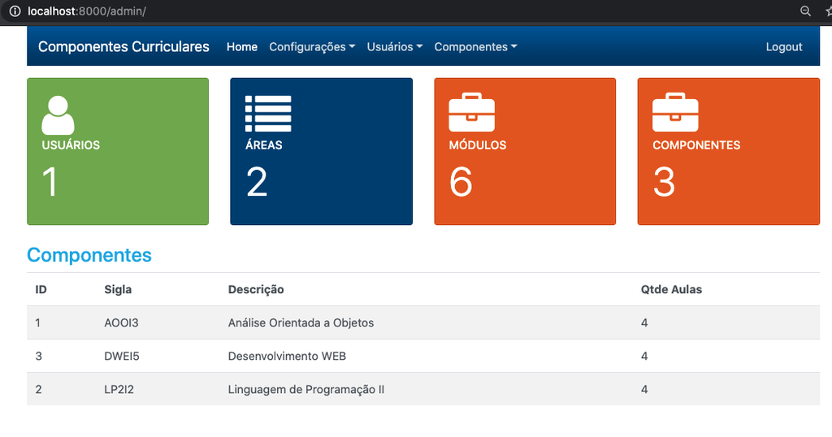

### 2.5. Personalizando a View.py

- Localize o arquivo **View.py** dentro da pasta **admin**.
- Edite o arquivo e insira o seguinte código.

```
# Substitui a home com o temnplate customizado admin.html (vamos criá-lo)
class HomeView(AdminIndexView):
    # Indicando que os arquivos css de formatação devem ser usados. Tanto o home quanto o cdn online.
    extra_css = [config.URL_MAIN + 'static/css/home.css','https://maxcdn.bootstrapcdn.com/font-awesome/4.7.0/css/font-awesome.min.css']                        <----- Adicione aqui
    @expose('/')
    def index(self):
        usuario_model = Usuario()

        ....
# --> Código omitido para facilitar o entendimento.
```

### 2.6. Criando o arquivo home.css

- Localize o arquivo **home.css** dentro da pasta **static/css**.

```
body, html {
    height:100%;
}
.py-2{
    overflow: hidden;
}
.card {
    overflow: hidden;
    padding: 0 10px;
    box-sizing: border-box;
    border-radius: 5px;
}

.card-body .rotate {
    z-index: 8;
    float: right;
    height: 100%;
}
.card-body .rotate i {
    color: rgba(20, 20, 20, 0.15);
    position: absolute;
    left: auto;
    right: 21px;
    bottom: 0px;
    display: block;
    -webkit-transform: rotate(-44deg);
    -moz-transform: rotate(-44deg);
    -o-transform: rotate(-44deg);
    -ms-transform: rotate(-44deg);
    transform: rotate(-44deg);
}
```

### 2.7. Visualizando as modificações

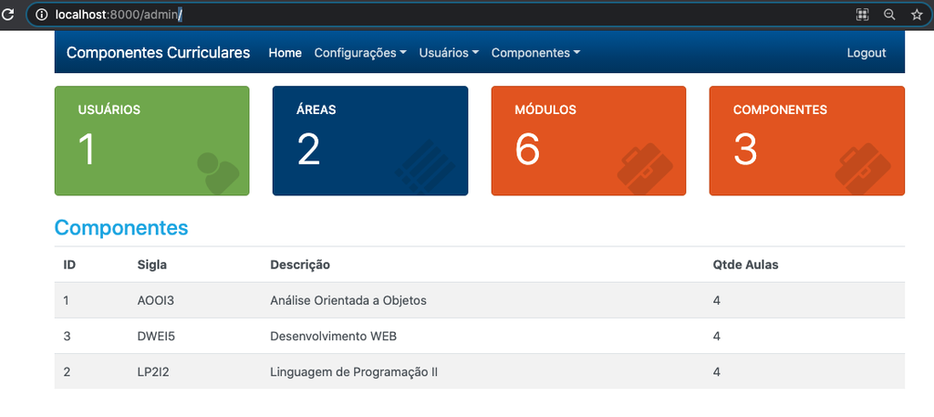

### ATENÇÃO

- **Lembre-se de encerrar o servidor ao final de cada aula**.
- **Lembre-se também, de desativar o ambiente virtual**.

### Referências

- Esta aula foi elaborada a partir do conteúdo disponibilizado em cada um dos links indicados no próprio texto.

### Perguntas

- Esclareça suas eventuais dúvidas durante as aulas.
- Ou pelo *E-mail*: paulagiancoli@ifsp.edu.br.
- Ou acesse [Github Ana Giancoli](https://anagiancoli.github.io) e solicite atendimento para o componente curricular.

*ADS - HTML5, CSS3, JS, FLASK - 5o. módulo*.  
Modelo e formato elaborado por profa. Ana Paula Müller Giancoli - BSD 2-Clause License. - Fevereiro.2021.